# VehiclePandas

```python
import pandas as pd
import numpy as np
import matplotlib.pyplot as plt
```

The attached spreadsheet (VehicleData.xls) contains the results of the inspections from 2000 onwards. The fields in the data are as follows:

```
1. The unique ID of the vehicle;
2. The type of vehicle;
3. The manufacturer;
4. The inspection score;
```

The client hands you this data and asks you to investigate the following questions:

1. How does the sample size vary from year-to-year? Are there any years that the DfBL should exclude from this analysis?
2. Assuming that the data is a representative sample of the population; does the condition of road-going vehicles appear to be changing over time? If so, is it deteriorating or improving?
3. Are there any particular vehicle types or manufacturers that the DfBL should pay special attention to? Would you suggest any changes to the sampling methodology to obtain better information for these types?
4. Since 2000 the vehicle inspectors have slowly improved the algorithm that they use to determine which vehicles to inspect more frequently, so that they are getting better at inspecting vehicles in poor condition more often. What effect could this have on the results?
5. Is DfBL conducting a sufficient number of inspections a year? Explain and justify your answer.

```python
file = 'VehicleData_csv_modified.csv'
df = pd.read_csv(file, parse_dates = ['FinancialYear'])

#format the time column
df.FinancialYear = df.FinancialYear.apply(lambda x: '-'.join([x[:4],x[4:]]))

#change to datetime data
df.FinancialYear = pd.to_datetime(df.FinancialYear, format='%Y-%m')
print(df.shape)
df.head()
```

```
(30305, 5)
```

|  | VehicleID | FinancialYear | VehicleType | Manufacturer | ConditionScore |
| --- | --- | --- | --- | --- | --- |
| 0 | 120 | 2011-12-01 | Heavy Goods Vehicle | DAF | 30 |
| 1 | 124 | 2011-12-01 | Heavy Goods Vehicle | MAN | 5 |
| 2 | 136 | 2011-12-01 | Heavy Goods Vehicle | DAF | 50 |
| 3 | 31 | 2009-10-01 | Light Goods Vehicle | Volkswagen | 80 |
| 4 | 149 | 2011-12-01 | Light Goods Vehicle | Renault | 50 |

---Quick Guess work---

Most of our questions require pivoting the data so as to either get a mean or count of the fields. For instance number

1. requires that we [pivot](https://pandas.pydata.org/pandas-docs/stable/reference/api/pandas.pivot_table.html) about the year and get a count
2. requires pivoting about the year and getting a mean of median of the ConditionScore
3. requires pivoting about the Manufacturer column and repeating the operation from number 2

---speculation---

Number four may require tracking the actual vehicles. And classifying them using the ConditionScore.

```python
#year by year sample size
sample_year = pd.pivot_table(df, index = 'FinancialYear', aggfunc = 'count')
sample_year
```

| FinancialYear | ConditionScore | Manufacturer | VehicleID | VehicleType |
| --- | --- | --- | --- | --- |
| 2000-01-01 | 545 | 545 | 545 | 545 |
| 2001-02-01 | 2338 | 2338 | 2338 | 2338 |
| 2002-03-01 | 3171 | 3171 | 3171 | 3171 |
| 2003-04-01 | 2597 | 2597 | 2597 | 2597 |
| 2004-05-01 | 2740 | 2740 | 2740 | 2740 |
| 2005-06-01 | 3447 | 3447 | 3447 | 3447 |
| 2006-07-01 | 3098 | 3098 | 3098 | 3098 |
| 2007-08-01 | 2610 | 2610 | 2610 | 2610 |
| 2008-09-01 | 2819 | 2819 | 2819 | 2819 |
| 2009-10-01 | 2057 | 2057 | 2057 | 2057 |
| 2010-11-01 | 2174 | 2174 | 2174 | 2174 |
| 2011-12-01 | 2709 | 2709 | 2709 | 2709 |

Using pivot and count this way let's you find if there are any missing values in each column. Since you aren't missing any data any one of the columns can act as your sample size so below I just chose VehicleID. The first thing that stands out to me is how the months go up in order by year, I'm not sure why it would be that way.

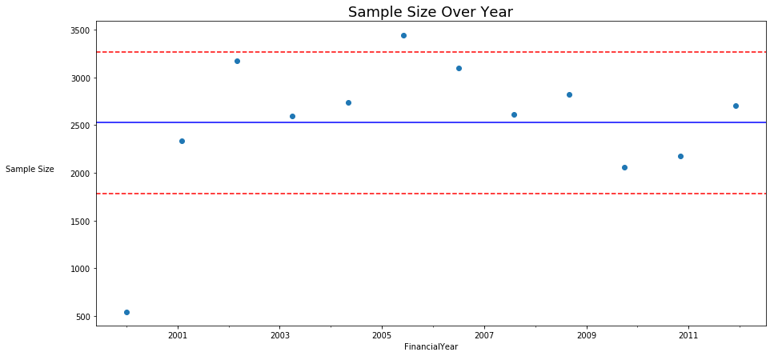

```python
f, ax = plt.subplots(figsize = (15,7))
sample_year.VehicleID.plot(style = '.',markersize = 12 ,ax = ax)

#plot the mean with +/- 1 standard deviation
plt.axhline(sample_year.VehicleID.mean(), color = 'b')
plt.axhline(sample_year.VehicleID.mean() + sample_year.VehicleID.std(), color = 'r', linestyle= '--')
plt.axhline(sample_year.VehicleID.mean() - sample_year.VehicleID.std(), color = 'r', linestyle='--')

#add some labels remove the legend
plt.ylabel('Sample Size', rotation=0, labelpad=50)
plt.title('Sample Size Over Year', fontsize = 18)

plt.show()
```

Here we have the sample size plotted for each year. The blue line represents the mean sample size and the red dash represents the mean +/- one standard deviation. This reveals that in the first year we have drastically undersampled the number of inspections and so that year should be dropped from further analysis. This data can easily be cleaved by querying the data for years not including this one. I will leave the data in though to see how including it could have changed our interpretations.

```python
#look at the mean condition
time_mean = pd.pivot_table(df, index = 'FinancialYear', values = ['ConditionScore'], aggfunc = [np.mean ,np.median ,np.std])
time_mean['mean_pstd'] = time_mean['mean', 'ConditionScore'] + time_mean['std','ConditionScore']
time_mean['mean_mstd'] = time_mean['mean', 'ConditionScore'] - time_mean['std','ConditionScore']
time_mean
```

| FinancialYear | mean ConditionScore | median ConditionScore | std ConditionScore | mean_pstd | mean_mstd |
| --- | --- | --- | --- | --- | --- |
| 2000-01-01 | 49.884404 | 50 | 25.168320 | 75.052724 | 24.716084 |
| 2001-02-01 | 51.943541 | 50 | 26.592542 | 78.536083 | 25.351000 |
| 2002-03-01 | 50.976033 | 50 | 26.877771 | 77.853804 | 24.098262 |
| 2003-04-01 | 49.539854 | 50 | 25.487052 | 75.026905 | 24.052802 |
| 2004-05-01 | 45.897810 | 50 | 25.588234 | 71.486044 | 20.309576 |
| 2005-06-01 | 45.643168 | 50 | 25.292859 | 70.936027 | 20.350309 |
| 2006-07-01 | 46.695287 | 50 | 25.338282 | 72.033569 | 21.357005 |
| 2007-08-01 | 47.454023 | 50 | 25.267120 | 72.721143 | 22.186903 |
| 2008-09-01 | 45.724016 | 50 | 25.434864 | 71.158880 | 20.289151 |
| 2009-10-01 | 44.690326 | 50 | 25.710447 | 70.400773 | 18.979878 |
| 2010-11-01 | 43.998160 | 50 | 25.155878 | 69.154039 | 18.842282 |
| 2011-12-01 | 44.445921 | 50 | 25.595964 | 70.041885 | 18.849957 |

It's important to look at the mean along with the median of your data, especially with small datasets. It seems that the median is the same for each sample year, which would mean that each year we don't have any extreme outliers. Below is a quick method of using a histogram to get a feel for the distribution of your samples.

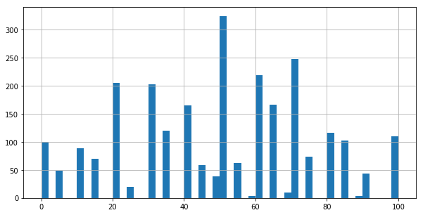

```python
ax =pd.pivot_table(data = df, index = 'FinancialYear', columns = 'VehicleID',values = 'ConditionScore').iloc[3].dropna().hist(bins = 50, figsize = (10,5))
```

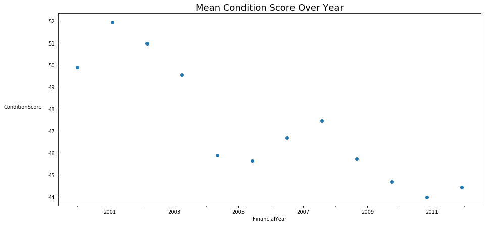

```python
#create the size of the image
f, ax = plt.subplots(figsize = (15,7))

#time mean is pivot table with index = year, values = score, aggfunc = mean
ax = time_mean['mean','ConditionScore'].plot(style = '.', markersize = 12)

#add some labels remove the legend
plt.ylabel('ConditionScore', rotation=0, labelpad=50)
plt.title('Mean Condition Score Over Year', fontsize = 18)
plt.show()
```

If appears the average condition score is trending down over time. The plot below is just to show how one could go about plotting the standard deviation with the average.

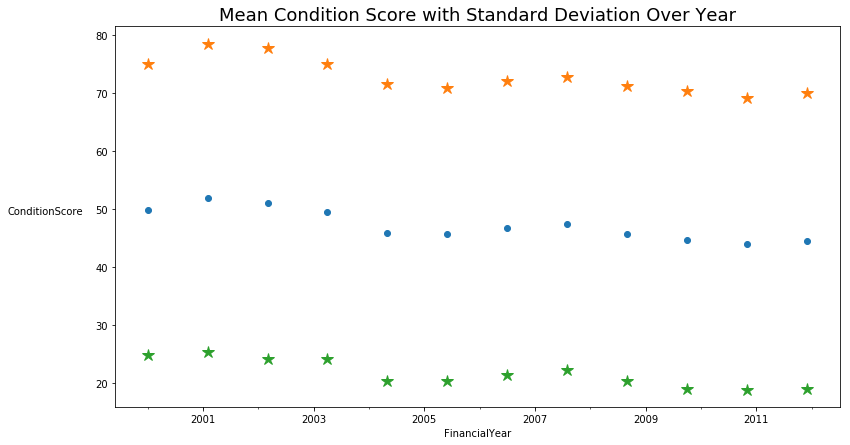

```python
#create the size of the image
f, ax = plt.subplots(figsize = (13,7))

#time mean is pivot table with index = year, values = score, aggfunc = mean
time_mean['mean','ConditionScore'].plot(style = '.', markersize = 12 , ax = ax)
time_mean['mean_pstd'].plot(style = '*', markersize = 12 , ax = ax)
time_mean['mean_mstd'].plot(style = '*', markersize = 12 , ax = ax)

#add some labels remove the legend
plt.ylabel('ConditionScore', rotation=0, labelpad=50)
plt.title('Mean Condition Score with Standard Deviation Over Year', fontsize = 18)
plt.show()
```

We took the time to see if we were oversampling by year, it may also be fun to look at the manufacturer sample size. We would need to do this if we wanted to draw any conclusion about condition score relative to manufacturer. We could even get the sample size for manufacturers each year and see if the number of cars per manufacturer being inspected each year is changing. This could let us know what kind of cars people are driving over time.

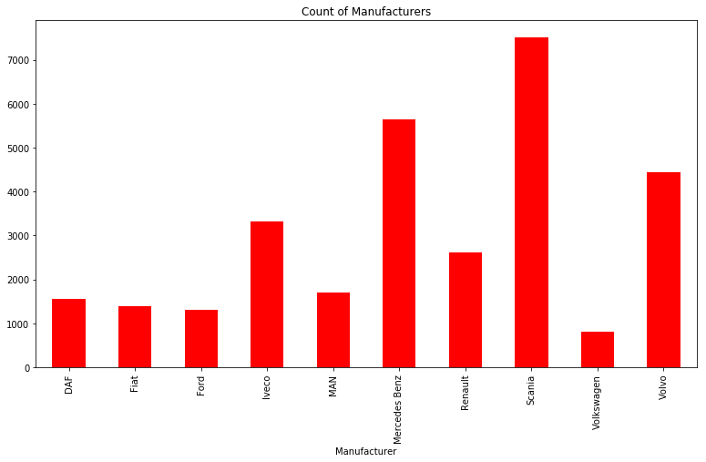

```python
#manufacturer sample sizes
f, ax = plt.subplots(figsize = (13,7))
ax = pd.pivot_table(df, index = 'Manufacturer', values = 'ConditionScore', aggfunc = 'count').plot.bar(ax = ax, color = 'r',
                                                                                                       legend = False, title = 'Count of Manufacturers')
```

We can see that there are many more scania then ford for instance, this would be important when it comes time to comparing data from each of these samples. One way you could combat this issue is by taking a random sampling of larger datasets so that they have the same number as the smaller ones. Below is a method for tracking the condition score for each manufacturer over time.

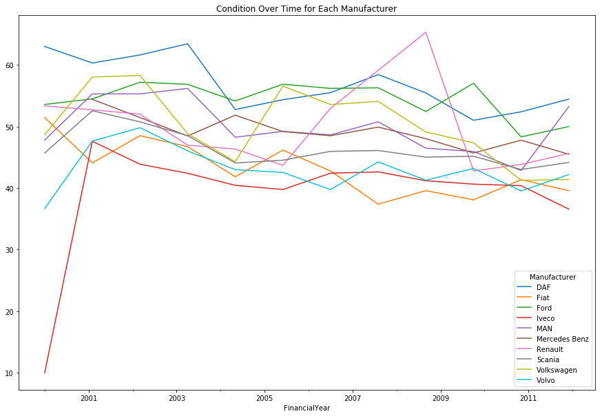

```python
sample_df = pd.pivot_table(df, index = 'FinancialYear',columns = 'Manufacturer', values = 'ConditionScore')
ax = sample_df.plot(figsize=(15,10), title = 'Condition Over Time for Each Manufacturer')
```

If the plot above is nauseating you can use the method below to look at each sample by itself or choose one of the methods from before to pick apart the dataframe and plot it.

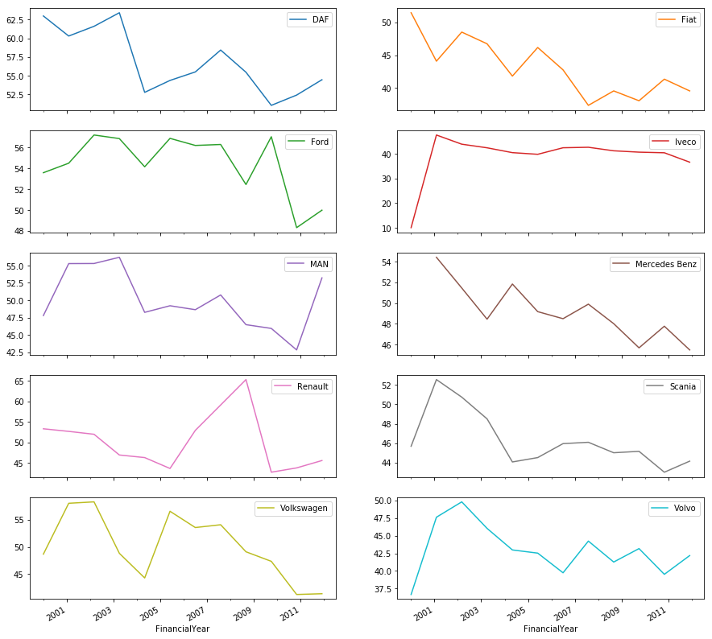

```python
ax = sample_df.plot(figsize=(15,15), subplots = True, layout=(5,2))
```

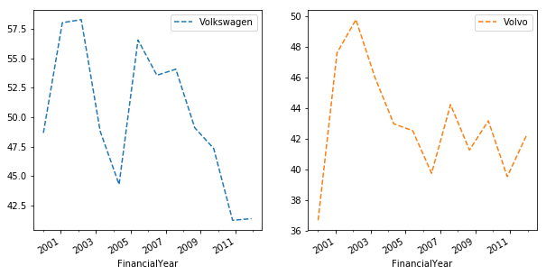

```python
ax = sample_df[['Volkswagen','Volvo']].plot(style = '--',figsize=(10,5), subplots = True, layout=(1,2))
```

We would like to know if the algorithm created to detect cars of with poor condition is working. If the algorithm was working we might expect that the number of cars inspected that were of poor condition to increase over the years. There are most likely several ways to do this. One quick method that I have used below is to get the ids of vehicles with average condition score below 50, which I labled as id_below and those above id_above. I then created a pivot table which shows the vehicel id and number of inspections of during each year.

Now we need to come up with a way to measure the frequency of inspections. I chose to use pandas df roll attribute and sum. So what it does is looks at the proceeding number of columns specified by the periods variable and sums them up. So it tells you the number of inspections in the x years where x is the period. I did this for ids below and above and used that information to create a plot.

```python
df[df.VehicleID == 120]
```

|  | VehicleID | FinancialYear | VehicleType | Manufacturer | ConditionScore |
| --- | --- | --- | --- | --- | --- |
| 0 | 120 | 2011-12-01 | Heavy Goods Vehicle | DAF | 30 |
| 4884 | 120 | 2009-10-01 | Heavy Goods Vehicle | DAF | 15 |
| 21654 | 120 | 2003-04-01 | Heavy Goods Vehicle | DAF | 30 |
| 27422 | 120 | 2001-02-01 | Heavy Goods Vehicle | DAF | 60 |

```python
ids = df.groupby(by = 'VehicleID').ConditionScore.mean().apply(lambda x: x >50)
id_above = ids.where(ids == True).dropna().index.tolist()
id_below = ids.where(ids == False).dropna().index.tolist()
```

```python
inspect_freq = pd.pivot_table(df, index = 'VehicleID', columns = 'FinancialYear' ,values = ['VehicleType'],
                   aggfunc={'VehicleType' : 'count',}).fillna(0)
inspect_freq.head()
```

| FinancialYear VehicleID | VehicleType 2000-01-01 | VehicleType 2001-02-01 | VehicleType 2002-03-01 | VehicleType 2003-04-01 | VehicleType 2004-05-01 | VehicleType 2005-06-01 | VehicleType 2006-07-01 | VehicleType 2007-08-01 | VehicleType 2008-09-01 | VehicleType 2009-10-01 | VehicleType 2010-11-01 | VehicleType 2011-12-01 |
| --- | --- | --- | --- | --- | --- | --- | --- | --- | --- | --- | --- | --- |
| 31 | 0.0 | 0.0 | 0.0 | 0.0 | 0.0 | 0.0 | 0.0 | 0.0 | 1.0 | 1.0 | 0.0 | 0.0 |
| 95 | 0.0 | 0.0 | 0.0 | 0.0 | 0.0 | 1.0 | 0.0 | 0.0 | 0.0 | 0.0 | 0.0 | 0.0 |
| 111 | 0.0 | 0.0 | 1.0 | 0.0 | 0.0 | 0.0 | 0.0 | 0.0 | 0.0 | 0.0 | 0.0 | 0.0 |
| 112 | 0.0 | 0.0 | 0.0 | 0.0 | 1.0 | 0.0 | 0.0 | 0.0 | 0.0 | 0.0 | 0.0 | 0.0 |
| 113 | 0.0 | 0.0 | 1.0 | 0.0 | 0.0 | 0.0 | 1.0 | 0.0 | 0.0 | 0.0 | 0.0 | 0.0 |

```python
inspect_freq.rolling(2, axis = 1).sum().loc[id_above].head()
```

| FinancialYear VehicleID | VehicleType 2000-01-01 | VehicleType 2001-02-01 | VehicleType 2002-03-01 | VehicleType 2003-04-01 | VehicleType 2004-05-01 | VehicleType 2005-06-01 | VehicleType 2006-07-01 | VehicleType 2007-08-01 | VehicleType 2008-09-01 | VehicleType 2009-10-01 | VehicleType 2010-11-01 | VehicleType 2011-12-01 |
| --- | --- | --- | --- | --- | --- | --- | --- | --- | --- | --- | --- | --- |
| 31 | NaN | 0.0 | 0.0 | 0.0 | 0.0 | 0.0 | 0.0 | 0.0 | 1.0 | 2.0 | 1.0 | 0.0 |
| 111 | NaN | 0.0 | 1.0 | 1.0 | 0.0 | 0.0 | 0.0 | 0.0 | 0.0 | 0.0 | 0.0 | 0.0 |
| 112 | NaN | 0.0 | 0.0 | 0.0 | 1.0 | 1.0 | 0.0 | 0.0 | 0.0 | 0.0 | 0.0 | 0.0 |
| 115 | NaN | 0.0 | 0.0 | 0.0 | 0.0 | 1.0 | 1.0 | 0.0 | 0.0 | 0.0 | 0.0 | 0.0 |
| 119 | NaN | 1.0 | 0.0 | 0.0 | 0.0 | 0.0 | 0.0 | 0.0 | 0.0 | 0.0 | 0.0 | 0.0 |

```python
inspect_freq.rolling(2, axis = 1).sum().loc[id_below].head()
```

| FinancialYear VehicleID | VehicleType 2000-01-01 | VehicleType 2001-02-01 | VehicleType 2002-03-01 | VehicleType 2003-04-01 | VehicleType 2004-05-01 | VehicleType 2005-06-01 | VehicleType 2006-07-01 | VehicleType 2007-08-01 | VehicleType 2008-09-01 | VehicleType 2009-10-01 | VehicleType 2010-11-01 | VehicleType 2011-12-01 |
| --- | --- | --- | --- | --- | --- | --- | --- | --- | --- | --- | --- | --- |
| 95 | NaN | 0.0 | 0.0 | 0.0 | 0.0 | 1.0 | 1.0 | 0.0 | 0.0 | 0.0 | 0.0 | 0.0 |
| 113 | NaN | 0.0 | 1.0 | 1.0 | 0.0 | 0.0 | 1.0 | 1.0 | 0.0 | 0.0 | 0.0 | 0.0 |
| 116 | NaN | 0.0 | 1.0 | 1.0 | 0.0 | 0.0 | 0.0 | 0.0 | 1.0 | 1.0 | 0.0 | 0.0 |
| 118 | NaN | 0.0 | 0.0 | 0.0 | 0.0 | 0.0 | 0.0 | 1.0 | 1.0 | 0.0 | 0.0 | 0.0 |
| 120 | NaN | 1.0 | 1.0 | 1.0 | 1.0 | 0.0 | 0.0 | 0.0 | 0.0 | 1.0 | 1.0 | 1.0 |

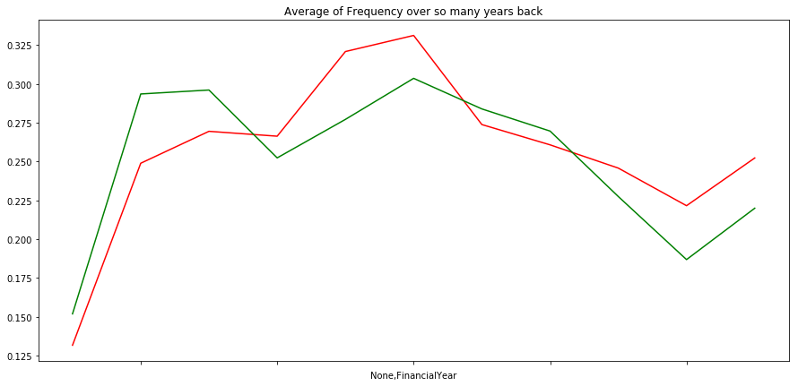

```python
f, ax = plt.subplots(figsize = (15,7))
inspect_freq.rolling(2, axis = 1).sum().loc[id_below].mean().plot(markersize = 12, color = 'r', label = 'below')
inspect_freq.rolling(2, axis = 1).sum().loc[id_above].mean().plot(markersize = 12, color = 'g', label = 'above')
plt.title('Average of Frequency over so many years back')
plt.show()
```

This plot really just gives us a sense for the amount of vehicles that are inspected for the past x years. We can see that there was a higher frequency of inspections during the middle of the time interval. It appears that the frequency of inspections of cars that have a lower condition scores overtakes the frequency of higher frequencies relaitvely speaking. The significance of this difference will have to be analyzed seperately. This was just one way to look at the problem.